# 盐湖城—黄石—大提顿 7天6晚行程

**日期：2026年7月9日–7月15日**  
**路线：SLC → West Yellowstone → Gardiner → Grand Teton/Jackson → SLC**  
**人数：3人，自驾，共住一间房或 cabin**

## 行程总览

| 日期 | 路线 | 住宿 |
| --- | --- | --- |
| 7/9 | 抵达 SLC；市区或 Antelope Island | Salt Lake City |
| 7/10 | SLC → West Yellowstone；Grand Prismatic 一带 | West Yellowstone |
| 7/11 | Old Faithful + Upper Geyser Basin | West Yellowstone |
| 7/12 | Norris + Mammoth + Lamar Valley | Gardiner |
| 7/13 | Canyon + Hayden + Mud Volcano + West Thumb → Grand Teton | Moran / Colter Bay / Jackson |
| 7/14 | Jenny Lake + Grand Teton 南部景点 → SLC | SLC Airport |
| 7/15 | 返程；晚班机可补盐湖城市区 | — |

## 目录

- 7/9 抵达盐湖城
- 7/10 SLC → West Yellowstone
- 7/11 Old Faithful + Upper Geyser Basin
- 7/12 Norris + Mammoth + Lamar Valley
- 7/13 黄石峡谷与湖区 → 大提顿
- 7/14 Grand Teton → SLC
- 7/15 返程
- 提前准备清单
- 住宿
- 天气和行李
- 花费估计
- 统一注意事项

## 7/9 周四｜抵达盐湖城

**驾驶强度：★☆☆☆☆ 步行强度：★☆☆☆☆**

### 安排

- 三人**下午**在 SLC 集合、机场取车
- 酒店 check-in
- 超市采购：早餐、饮用水、零食、水果、简易午餐
- 根据全部人员到达时间二选一：
  - **Antelope Island State Park**：Great Salt Lake、bison、日落
  - **Utah State Capitol + Temple Square / City Creek**

  Antelope Island 每天开放至 10:00 PM，因此下午抵达后仍可前往；如果有人到得较晚，直接留在盐湖城市区即可。([Utah State Parks](https://stateparks.utah.gov/parks/antelope-island/))

**景点介绍**

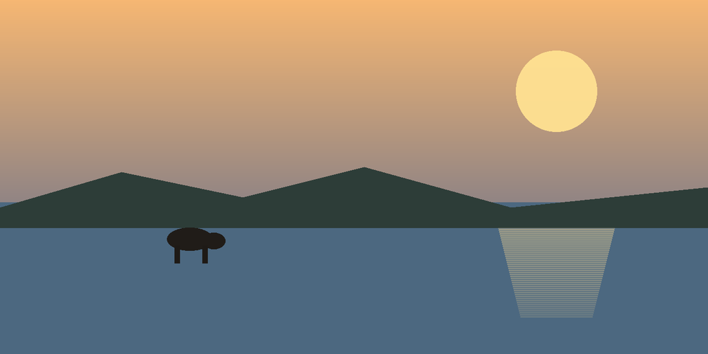

Antelope Island 日落与野牛示意图

#### 1. Utah State Capitol (犹他州议会大厦)

- **一句话定义：** 犹他州的“权力中心”和最棒的观景台。
- **亮点：** 坐落在市中心北侧的山丘上，建筑风格宏伟，有着经典的圆顶。它不仅是州政府办公的地方，也是盐湖城的**最佳免费拍照点**之一。从大厦前面的台阶往下看，可以俯瞰整座盐湖城市区和远处的雪山，视野极其开阔。

#### 2. Temple Square / Conference Center (圣殿广场/会议中心)

- **一句话定义：** 摩门教（耶稣基督后期圣徒教会）的全球总部及核心区域。
- **亮点：**
  - **Temple Square：** 是盐湖城的灵魂，以那座著名的、拥有高耸尖塔的盐湖城圣殿（Salt Lake Temple）为核心。虽然圣殿常年处于翻新状态，但周边花园修剪得非常精致，环境非常安静肃穆。
  - **Conference Center：** 就在广场隔壁，是一个规模巨大的现代建筑。它最有特色的是**楼顶的大型空中花园**，不仅绿化好，还可以登高望远，拍摄到圣殿广场的全貌。

**3. Antelope Island Sunset (羚羊岛日落)** * **一句话定义：** 犹他州最震撼的自然景观之一，盐湖上的“天空之镜”。 * **亮点：** 这里位于大盐湖（Great Salt Lake）之中。因为周围地势开阔、视野无遮挡，日落时分，天空的霞光会完整地倒映在平静的盐湖水面上，产生一种类似“天空之镜”的梦幻视觉效果。而且因为这里也是“国际暗空公园”，日落之后，这里的星空也非常值得一看。此外，岛上还有成群的野牛和羚羊，是观赏野生动物的好地方。

### 住宿：Salt Lake City

机场附近或 downtown 均可。

## 7/10 周五｜SLC → West Yellowstone｜地热初体验

**建议 8:00 AM 前出发** 预计纯驾驶约 5–6 小时，中间安排午餐和休息。沿途可选顺路停留参考7/14的计划。

**驾驶强度：★★★★☆ 步行强度：★★☆☆☆**

### 下午景点

1. **Grand Prismatic Spring Overlook**
   - 从 Fairy Falls Trailhead 前往俯瞰点
   - 下午蒸汽通常相对较少，颜色更容易看清
2. **Midway Geyser Basin Boardwalk**
   - 从近距离看 Grand Prismatic、Excelsior Geyser
3. **Fountain Paint Pot**
   - 泥浆泉、热泉、喷气孔和小型间歇泉集中在一条短步道上

如果抵达较晚，只保留 Grand Prismatic Overlook 和 Fountain Paint Pot。

**景点介绍**

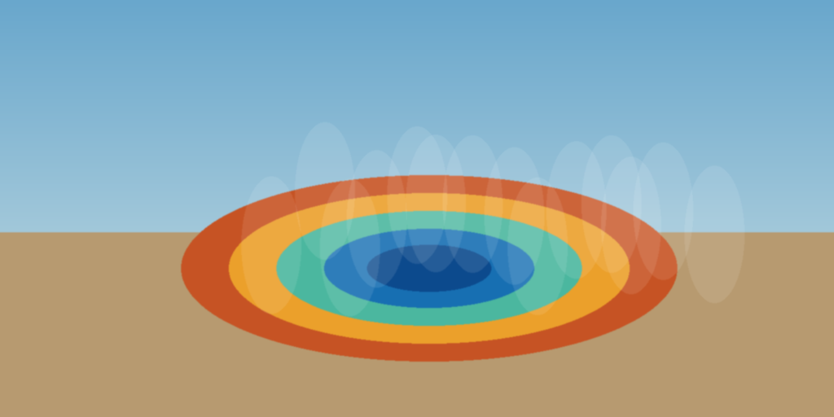

Grand Prismatic Spring 示意图

#### 1. Grand Prismatic Spring Overlook (大棱镜俯瞰点)

- **一句话定义：** 拍摄“上帝调色盘”大棱镜全貌的最佳机位。
- **亮点：** 需要从 **Fairy Falls Trailhead** 徒步约 15-20 分钟到达。下午时分，因气温升高，水面蒸汽大幅减少，大棱镜明艳的蓝、橙、黄色色彩最为清晰，是拍摄大片的最佳时间。

#### 2. Midway Geyser Basin Boardwalk (中途间歇泉盆地木栈道)

- **一句话定义：** 近距离“身临其境”感受地热震撼的木栈道。
- **亮点：** 可以在平视视角下，近距离观察巨大的大棱镜水域及旁边的 **Excelsior Geyser (出云间歇泉)**。这里能让你清晰感受到热泉涌动的力量和蓝宝石般深邃的泉水质感。

#### 3. Fountain Paint Pot (颜料罐喷泉区)

- **一句话定义：** 黄石地热景观的“微缩博览会”，一次看全所有地貌。
- **亮点：** 在一条非常短且轻松的步道上，即可集中欣赏到**泥浆泉**（咕嘟冒泡的泥浆）、**热泉**、**喷气孔**及小型**间歇泉**。它是快速了解黄石地热多样性的最佳“开胃菜”。

### 住宿：West Yellowstone

优先住西门 20 分钟车程以内；Island Park 只有在价格明显更低时再考虑。

## 7/11 周六｜Old Faithful + Upper Geyser Basin

**建议 6:15–6:30 AM 从酒店出发，7:00 AM 前进入西门。**

**驾驶强度：★★☆☆☆ 步行强度：★★★★☆**

### 主线

1. **Old Faithful Visitor Education Center**
   - 查看当天主要 geyser eruption prediction
2. **Old Faithful**
3. **Upper Geyser Basin Trail**
   - Castle Geyser
   - Grand Geyser
   - Riverside Geyser
   - Daisy Geyser 等
4. **Morning Glory Pool**
   - 从 Old Faithful 沿步道往返，不要直接把导航终点设成公路位置

### 下午二选一

**A. 徒步版**

- Mystic Falls Trail 或
- Fairy Falls Trail，前一天只看 overlook 时选择

**B. 轻松版**

- Black Sand Basin
- Biscuit Basin：仅在当日确认开放时前往
- Old Faithful Inn
- 在游客中心等一轮其他可预测喷泉

**景点介绍**

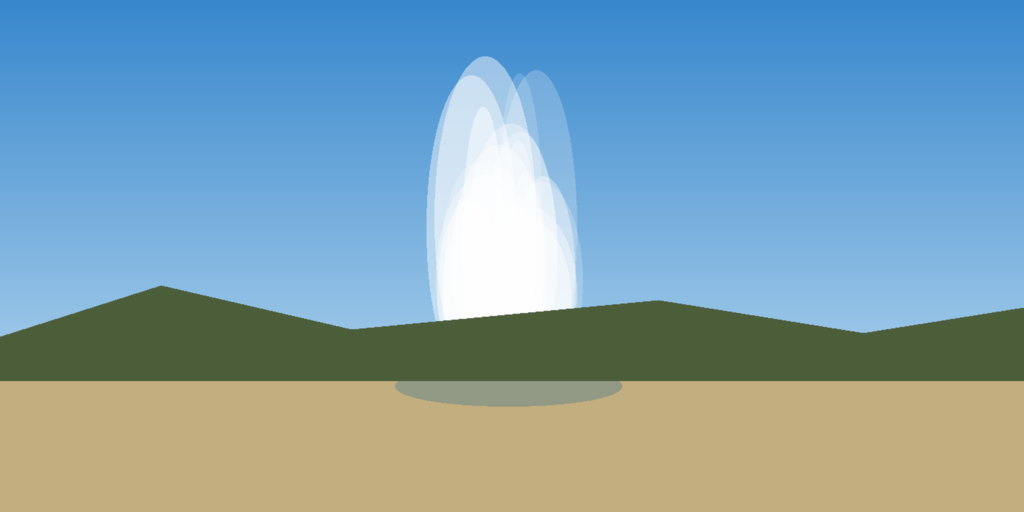

Old Faithful 喷发示意图

#### 1. Old Faithful Visitor Education Center (老忠实游客教育中心)

- **一句话定义：** 黄石地热情报的“总调度室”。
- **亮点：** 这里提供最权威、实时的**间歇泉喷发预测时间表**。进园后第一站必看，通过预测表你可以规划好一整天的追泉行程，避免错过“老忠实”或 Grand Geyser 等著名喷泉的喷发。

#### 2. Old Faithful (老忠实喷泉)

- **一句话定义：** 黄石的象征，世界上最守时的喷泉。
- **亮点：** 虽然不是黄石最高或水量最大的喷泉，但它极高的喷发频率和近乎准时的节奏使其成为必看景观。喷发时水柱冲天，场面极为壮观，是黄石旅行的“打卡仪式”。

#### 3. Upper Geyser Basin Trail (上间歇泉盆地步道)

- **一句话定义：** 全球间歇泉密度最高、类型最丰富的“地热步行长廊”。
- **亮点：** 步道连接了多个名泉：**Castle Geyser**（古堡般的钙化沉积）、**Grand Geyser**（极其壮观且不规则的大型喷泉）、**Riverside Geyser**（横跨河面的奇景）和 **Daisy Geyser**。这里适合花上半天时间深度漫步。

#### 4. Morning Glory Pool (牵牛花池)

- **一句话定义：** 上间歇泉盆地步道尽头的梦幻之泉。
- **亮点：** 以其形似牵牛花、色彩从深蓝渐变到橘红的奇特外观闻名。沿步道步行前往，不仅能看到沿途众多小型地热景观，最后看到这汪绚丽的池水时，会有极佳的成就感。

#### 5. Mystic Falls Trail (神秘瀑布步道)

- **一句话定义：** 兼具地热景观与瀑布徒步的双重体验。
- **亮点：** 这条步道不仅能看到充满硫磺味的热泉地貌，还能深入峡谷，看到清凉奔流的神秘瀑布。相比大平原，这里的视野更多变，且游客相对较少，徒步体验感极佳。

#### 6. Fairy Falls Trail (仙女瀑布步道)

- **一句话定义：** 近距离观赏黄石最高之一的悬挂瀑布。
- **亮点：** 若前一天已看过大棱镜俯瞰点，可继续前行深入步道抵达仙女瀑布。这片区域环境静谧，瀑布如丝带般从岩壁坠下，是亲近大自然的热门选择。

#### 7. Black Sand Basin (黑沙盆地)

- **一句话定义：** 色彩对比强烈、精致小巧的地热盆地。
- **亮点：** 因为含有黑色的火山碎屑岩而得名，这里的泉水颜色如翡翠般碧绿，与黑色大地对比鲜明，非常适合拍照。

#### 8. Biscuit Basin (饼干盆地)

- **一句话定义：** 因地震而形成的奇异地热地貌。
- **亮点：** 步道平坦易行，可以看到 Sapphire Pool 等颜色极具冲击力的泉水。*注：此地地热活动活跃，行前请务必在游客中心确认当日是否开放。*

#### 9. Old Faithful Inn (老忠实旅馆)

- **一句话定义：** 全球规模最大的原木建筑之一。
- **亮点：** 这座拥有百年历史的国家历史地标建筑，由原木和石材堆砌而成，室内大厅极具震撼力。即便不住在这里，坐在它的木制大堂里感受历史氛围也是一种顶级享受。

### 住宿：West Yellowstone

## 7/12 周日｜Norris + Mammoth + Lamar Valley

**退房**后转移到黄石北部。

**驾驶强度：★★★★☆ 步行强度：★★★☆☆**

### 路线

1. **Norris Geyser Basin**
   - Porcelain Basin
   - Back Basin 根据时间和体力决定是否完整走
2. **Mammoth Hot Springs**
   - Upper Terraces
   - Lower Terraces
3. **Tower Fall / Calcite Springs Overlook**
   - 时间足够再停
4. **Lamar Valley**
   - 下午至傍晚观察 bison、elk、pronghorn
   - 狼和熊通常需要望远镜或长焦镜头

**景点介绍**

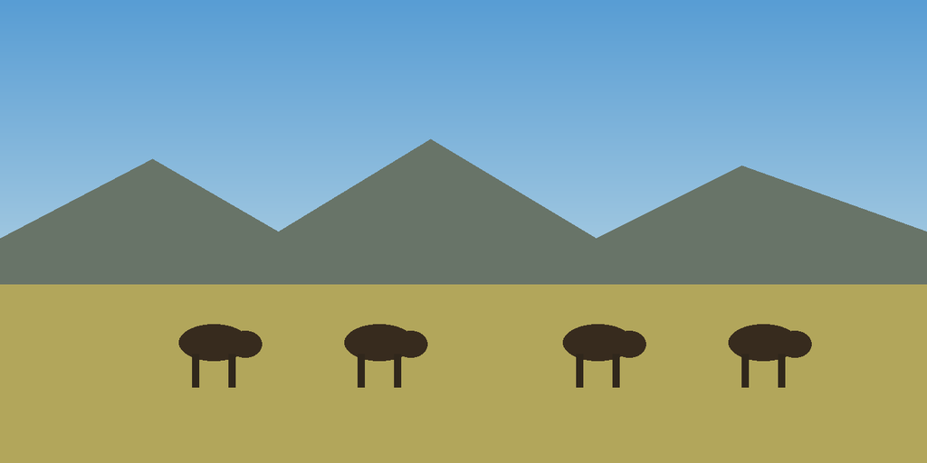

Lamar Valley 野牛与山谷示意图

#### 1. Porcelain Basin (瓷盆地)

- **一句话定义：** 黄石最热、最活跃、景观最诡异的喷泉区。
- **亮点：** 步道布满钙华沉积，整片区域寸草不生，烟雾缭绕。这里到处是嘶嘶作响的喷气孔和酸性热泉，视觉上有一种极具冲击力的“荒凉外星感”。

#### 2. Back Basin (后盆地)

- **一句话定义：** 穿梭于森林与地热泉之间的宁静步道。
- **亮点：** 相比瓷盆地的荒凉，这里植被更丰富，步道深入林中。你可以看到著名的 Echinus Geyser（海胆间歇泉）。*建议：若体力充沛可完整环行，若时间有限，仅走主要步道即可感受其深邃幽静。*

#### 3. Lower Terraces (下阶梯)

- **一句话定义：** 呈现出阶梯状流水的黄石经典“梯田”。
- **亮点：** 这里最著名的是 **Palette Spring**，五彩斑斓的钙化岩体如同凝固的瀑布，是猛犸象地区拍照最出片的地方。木栈道平坦，适合漫步观赏。

#### 4. Upper Terraces (上阶梯)

- **一句话定义：** 俯瞰地热奇观的高处视角。
- **亮点：** 这里有一条环形步道，你可以看到许多不再活跃、呈现干枯白色的钙华台地，带有一种肃穆的苍凉美感。在这里可以从更高角度审视整个猛犸象地热区的规模。

#### 5. Tower Fall / Calcite Springs Overlook (塔瀑/方解石泉俯瞰点)

- **一句话定义：** 峡谷间的壮丽水瀑与地质景观。
- **亮点：** 塔瀑以其周围如尖塔般的岩石柱而闻名。**Calcite Springs Overlook** 则可以清晰地看到黄石河底冒出的温泉与硫磺喷气，这里更像是一个观察峡谷地质演变的地标。*建议：时间充裕时停留，此处停车方便。*

#### 6. Lamar Valley (拉马尔山谷)

- **一句话定义：** 黄石的“美洲塞伦盖蒂”，野生动物的天然乐园。
- **亮点：** 这是黄石观赏大型食草动物（如美洲野牛 Bison、麋鹿 Elk、叉角羚 Pronghorn）的最佳地带。下午至傍晚是动物活跃期，它们常成群出现在草原上。若想寻找远处的狼或熊，建议携带望远镜或长焦镜头观察。

### 当晚 & 住宿

从 Lamar Valley 返回 Gardiner。不要在天黑后长时间停留在道路中央观察动物。

**住宿：Gardiner**

2026年 Mammoth 附近 Gardner River High Bridge 可能出现最多约15分钟单车道延误，园内其他路段的 chip sealing 也可能造成最多约30分钟延误。([National Park Service](https://www.nps.gov/yell/planyourvisit/parkroads.htm))

## 7/13 周一｜黄石峡谷与湖区 → 大提顿

**全程最长的一天，建议 6:00–6:30 AM 出发。**

**驾驶强度：★★★★★ 步行强度：★★★☆☆**

### 路线

1. **Grand Canyon of the Yellowstone**
   - Artist Point
   - Brink of the Lower Falls
   - Upper Falls View
   - 三者时间不足时优先 Artist Point + Brink of the Lower Falls
2. **Hayden Valley**
   - 沿途观察 bison
3. **Mud Volcano**
   - Dragon’s Mouth Spring
   - Mud Volcano boardwalk
4. **Yellowstone Lake**
   - Lake Hotel / Fishing Bridge 短暂停留
5. **West Thumb Geyser Basin**
   - 湖边蓝色热泉和 Yellowstone Lake 同框
6. 经 South Entrance 进入 Grand Teton
7. 时间允许可停：
   - Jackson Lake
   - Colter Bay（短暂停留；Kayak 移至 7/14 可选活动）
   - Oxbow Bend

**景点介绍**

[figure not shown]

Yellowstone Canyon 示意图

#### 1. Grand Canyon of the Yellowstone (黄石大峡谷)

- **一句话定义：** 黄石国家公园最震撼的“地质裂痕”与壮丽瀑布。
- **亮点：** **Artist Point** 提供拍摄大峡谷和瀑布的经典明信片视角；**Brink of the Lower Falls** 则带你走到瀑布顶部边缘，近距离感受万马奔腾的震撼；**Upper Falls View** 提供瀑布上方视角。若时间有限，**Artist Point + Brink of the Lower Falls** 是必选方案。

#### 2. Hayden Valley (海登山谷)

- **一句话定义：** 深入黄石心脏地带的野生动物观察天堂。
- **亮点：** 这是一片开阔的草甸，是观测**美洲野牛 (Bison)** 的核心地带。成群的野牛常会横穿公路，是感受黄石自然野性、体验“动物堵车”的绝佳地点。

#### 3. Mud Volcano (泥火山区)

- **一句话定义：** 充满神秘感与硫磺味道的奇异地热区。
- **亮点：** **Dragon’s Mouth Spring (龙口泉)** 极具特色，泉水从洞穴中涌出并伴随类似怒吼的声响和水汽；**Mud Volcano boardwalk** 则展示了不断翻滚的泥浆泉，呈现出一种原始且略带惊悚的地质景观。

#### 4. Yellowstone Lake (黄石湖)

- **一句话定义：** 高海拔火山口上的宁静明珠。
- **亮点：** **Lake Hotel** 是一座历史悠久的湖畔旅馆，拥有绝佳的观湖视角；**Fishing Bridge** 则是连接湖区与河道的标志性古桥，非常适合短暂停留，感受湖光山色的辽阔。

#### 5. West Thumb Geyser Basin (西拇指间歇泉盆地)

- **一句话定义：** 黄石唯一一个紧邻巨大湖泊的地热奇观。
- **亮点：** 这里拥有独特的湖边热泉，最著名的是蓝色热泉与背后的黄石湖同框。你可以在这里欣赏到热泉的色彩与深邃的湖蓝交织，是拍照极其出片的“视觉组合”。

#### 6. Jackson Lake (杰克逊湖)

- **一句话定义：** 坐拥大提顿群峰映衬的镜面湖泊。
- **亮点：** 湖水极其清澈，背景是雄伟的大提顿山脉。这里是大提顿南下途中的绝佳观景台，山峰与湖水的倒影是摄影爱好者的心头好。

#### 7. Colter Bay (科尔特湾)

- **一句话定义：** 深入湖区的休闲港湾。
- **亮点：** 这里的步道可以深入湖岸边，视野极其开阔，是享受大提顿宁静、休息或补充物资的理想中转站。

#### 8. Oxbow Bend (牛轭弯)

- **一句话定义：** 大提顿公园内最完美的山水构图视角。
- **亮点：** 蛇河 (Snake River) 在此处形成了一个优美的 S 形弯道，晨昏时刻这里是观看和拍摄大提顿群峰、麋鹿与水鸟的最佳地点，构图自带电影质感。

### 住宿优先顺序

1. **Moran / Colter Bay**：次日路线最顺
2. **Jackson**：餐厅和住宿选择多
3. **Victor / Driggs**：价格低时采用，但次日需额外翻越 Teton Pass

## 7/14 周二｜Grand Teton → SLC

**驾驶强度：★★★★☆ 步行强度：★★★★☆**

### 日出地点

> 由于山脉位于公园西侧，日出时太阳会从东边升起，光线首先照亮大提顿山峰的顶部，形成著名的“山峰染金”效果。
- 住 Moran / Colter Bay：**Oxbow Bend**
- 住 Jackson：**Schwabacher Landing 或 Mormon Row**

> 建议在日出前 30-40 分钟到达。因为在太阳真正跳出地平线之前，山峰就已经开始变色了。

> 即便是夏天，大提顿清晨的山区气温也非常低（有时接近冰点）。一定要穿防风外套，带上热水瓶。

### 上午核心活动

**Jenny Lake Shuttle Boat + 徒步**

1. 7:00–7:30 AM 到 Jenny Lake 停车
2. 坐 shuttle boat 到西岸
3. 徒步：
   - Hidden Falls
   - Inspiration Point
   - 有体力可继续进入 Cascade Canyon 一小段
4. 坐船返回，或单程坐船、另一程绕湖步行

2026年 Jenny Lake shuttle 在7月运行时间为 7:00 AM–7:00 PM，不接受预约，约每10–15分钟一班；成人往返票为 $20。([Jenny Lake Boating](https://jennylakeboating.com/schedule/))

### 下午景点与可选活动

**可选活动：Colter Bay Kayak**

- 仅在上午 Jenny Lake 行程结束较早、且不影响 3:00–4:00 PM 离开大提顿时考虑
- 如需更完整的划船体验，建议改为 7/16 返程

根据时间选择 2–3 个：

- Chapel of the Transfiguration
- Mormon Row
- Schwabacher Landing
- Snake River Overlook
- Grand Teton National Park 南门标志

**景点介绍**

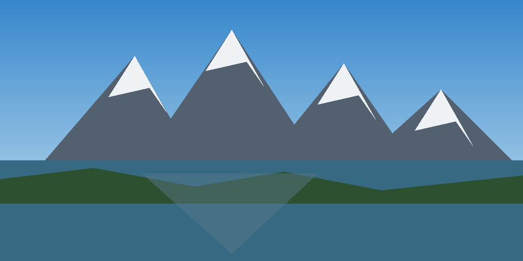

Jenny Lake 与 Teton Range 示意图

#### 1. Jenny Lake Shuttle Boat (珍妮湖接驳船)

- **一句话定义：** 深入大提顿核心山区最省时省力的“水上捷径”。
- **亮点：** 这条航线跨越珍妮湖，能让你快速抵达湖西岸的步道起点，省去绕湖数公里的路程。早班船清晨游客较少，湖面平静如镜，是拍摄山峰倒影的绝佳机会。*注：现场排队买票，建议尽早出发以避开高峰。*

#### 2. Hidden Falls (隐蔽瀑布)

- **一句话定义：** 隐藏在峡谷深处的壮丽水幕。
- **亮点：** 从码头步行一小段即可到达。瀑布虽高，但隐匿在茂密的森林中，水流顺着岩石倾泻而下，声势浩大，是徒步线路上最受欢迎的凉爽打卡点。

#### 3. Inspiration Point (灵感点)

- **一句话定义：** 俯瞰珍妮湖全景的极致观景点。
- **亮点：** 从隐蔽瀑布继续上行一段陡坡即可到达。站在高处，珍妮湖如同蓝宝石般镶嵌在群山之中，视野极其开阔，是俯瞰整个山谷壮美景观的视觉高地。

#### 4. Cascade Canyon (卡斯克德峡谷)

- **一句话定义：** 大提顿心脏地带的原始冰川峡谷。
- **亮点：** 若有体力深入此处，四周高耸的雪山峭壁会让你感受到深邃的压迫感。这里是观赏野生动物（尤其是驼鹿 Moose）的热门地带，是体验大提顿荒野感的精髓。

#### 5. Chapel of the Transfiguration (显圣容礼拜堂)

- **一句话定义：** 窗框装帧着大提顿群峰的灵性小屋。
- **亮点：** 这座小木屋最著名的设计在于其圣坛后的巨大玻璃窗，透过窗户可直接望见圣洁的大提顿山脉，完美诠释了宗教与自然和谐共生的宁静感。

#### 6. Mormon Row (摩门教徒排屋)

- **一句话定义：** 西部荒野中定格时间的经典人文地标。
- **亮点：** 这里的历史谷仓（Mormon Barn）是大提顿最经典的摄影构图，古朴破旧的木屋背景下是雄伟的山峰，不仅有浓厚的历史底蕴，也是拍摄日出或日落的绝佳背景。

#### 7. Schwabacher Landing (施瓦巴赫码头)

- **一句话定义：** 拥有绝佳水面反射效果的摄影秘境。
- **亮点：** 蛇河在此处变得极其平缓，形成了完美的镜面效果，能清晰地倒映出整排大提顿山峰，是摄影师捕捉山峦与河谷构图的首选之地。

#### 8. Snake River Overlook (蛇河观景台)

- **一句话定义：** 欣赏蛇河穿过山谷之美的经典机位。
- **亮点：** 曾被著名摄影师安塞尔·亚当斯（Ansel Adams）定格过。在这里可以俯瞰蛇河在茂密森林中蜿蜒流动的壮丽曲线，背景则是群峰矗立，展现了雄浑的地理层次感。

#### 9. Grand Teton National Park 南门标志

- **一句话定义：** 仪式感十足的公园边界地标。
- **亮点：** 位于公园南部入口处，木质的公园大门标志与背后起伏的山脉形成经典的“到此一游”画面，是结束大提顿行程前完美的留影点。

**沿途可选顺路停留（Grand Teton → SLC）**

### 1. Jackson Town Square

- 鹿角拱门、咖啡和早午餐补给
- 如果住宿在 Jackson，可在离开前短暂停留

### 2. Afton / Star Valley

- 回程中的加油、用餐和驾驶休息点
- Afton 镇中心有大型鹿角拱门，可快速拍照

### 3. Bear Lake Scenic Route（仅适合时间充足）

- 湖水颜色突出，适合夏季短停
- 相比最快回 SLC 的路线会增加时间；7/15 返程版通常不建议绕行
- 如果改为 7/16 返程，可作为 7/15 的可选路线

### 4. Lava Hot Springs（仅适合 7/16 返程版）

- 温泉池与河上漂流等活动集中
- 需要至少半天，不适合塞入 7/14 晚间回 SLC 的安排

**7/14 主方案只安排加油和用餐休息，不额外增加耗时活动。**

### 返回 SLC

建议 **3:00–4:00 PM 离开 Grand Teton**，轮换驾驶，晚上入住 SLC 机场附近。

2026年大提顿部分路段施工：北部 Park Road 白天可能延误约15分钟，Moose附近路口预计延误约20分钟；行程中预留至少30分钟机动时间。([National Park Service](https://www.nps.gov/grte/planyourvisit/road-construction.htm))

**住宿：SLC Airport 附近**

## 7/15 周三｜盐湖城 → 返程

### 航班较早

- 酒店退房
- 加油、还车
- 返程航班

### 航班较晚

上午可安排：

- Utah State Capitol
- Temple Square
- Conference Center
- City Creek Center
- 午餐后前往机场

# 提前准备清单

## 现在立即订

### 1. 机票

- Boston两人的早班 United
- San Diego朋友的往返航班
- 尽量安排7/9下午汇合
- 7/15返程建议不要选择过早、转机过紧的航班
- 确认行李额度

### 2. 酒店

住宿地点和花费估计见这里。按顺序优先订：

1. West Yellowstone：7/10–7/12
2. Gardiner：7/12–7/13
3. Moran / Jackson：7/13–7/14
4. SLC：7/9和7/14

全部优先选择可免费取消。

### 3. 租车

预订时逐项确认：

- SLC机场取车、SLC机场还车
- 7/9实际取车时间
- 7/15实际还车时间
- unlimited mileage
- additional driver fee
- full-to-full fuel policy
- 是否限制进入Montana、Wyoming、Idaho
- 信用卡押金要求
- roadside assistance是否包含
- 取消政策

### 4. 驾驶员与驾照

- 持美国驾照的 29/30 岁同行人作为 primary renter，预订、驾照和付款信用卡姓名保持一致
- 持中国驾照的同行人只有在租车公司确认接受中国驾照原件 + 护照 + 英文翻译件/所需文件，并正式列入合同后才能驾驶
- 两名司机必须一起到柜台办理；提前向 SLC 机场实际门店确认 additional driver 费用和文件要求
- 24 岁同行人不驾驶，不加入合同，因此不产生 under-25 driver fee
- 未列入租车合同的人不要驾驶

### 4. 确认租车保险

检查：

- 个人汽车保险是否覆盖 rental car
- 信用卡是否提供 collision damage waiver
- 是 primary coverage 还是 secondary coverage
- 是否覆盖 SUV
- 是否要求用该卡支付全部租车费用

**不要在不清楚信用卡保障时直接拒绝所有保险，也不要在已经有充分保障时重复购买柜台高价保险。**

## 出发前1–2周

### 国家公园

- 确认由谁购买 annual pass
- 准备对应的 driver’s license / state ID
- 可以提前在线购买，也可以入口购买
- Yellowstone和Grand Teton均不需要 vehicle reservation。([National Park Service](https://www.nps.gov/yell/planyourvisit/index.htm?utm_source=chatgpt.com))

### 地图和网络

- 下载 NPS App
- 下载 Yellowstone 离线地图
- 下载 Grand Teton 离线地图
- 下载 Google Maps 离线区域
- 把酒店、航班、租车确认页截图保存

### 路况

Yellowstone道路状态可能快速变化，2026年部分工程可能造成最多约30分钟延误；出发前和每天早上都应查看官方道路状态。([National Park Service](https://www.nps.gov/yell/planyourvisit/parkroads.htm?utm_source=chatgpt.com))

### Jenny Lake

你们计划坐的是 shuttle boat：

- 不需要提前买票
- 当天现场排队购买
- 7月运行时间通常为 7:00 AM–7:00 PM
- 成人往返 $20

如果改为一小时 narrated scenic cruise，则建议提前预约。([Jenny Lake Boating](https://jennylakeboating.com/))

## 到达SLC当天采购

- 3罐 bear spray，或确认后续租赁
- 水和电解质饮料
- 早餐和午餐食材
- soft cooler + 冰
- 防晒霜和驱蚊液
- 纸巾、湿巾、垃圾袋
- 必要时购买便宜望远镜

# 住宿

**约束：** - 3 adults - 需要 2 queen beds，或 2 queen + sofa bed - 免费停车 - 最好含早餐 - 优先 free cancellation

| 日期 | 地点 | 晚数 | 预计每晚含税价格 |
| --- | --- | --- | --- |
| 7/9 | Salt Lake City | 1 | $140-170 |
| 7/10–7/11 | West Yellowstone | 2 | $350-450 |
| 7/12 | Gardiner | 1 | $270-360 |
| 7/13 | Moran / Colter Bay / Jackson | 1 | $320-480 |
| 7/14 | SLC Airport | 1 | $140-170 |
| **总计** |  | **6晚** | $1,570-2,080 |

# 天气和行李

现在距离7月9日仍较远，精确逐日预报要等到出发前约7–10天再看。季节上会同时经历 **SLC炎热干燥** 和 **黄石、大提顿清晨寒凉**。

## 温度参考

| 地点 | 7月白天 | 夜间/清晨 |
| --- | --- | --- |
| Salt Lake City | 约 90–95°F / 32–35°C | 约 65°F / 18°C |
| Mammoth / 黄石低海拔 | 约 83°F / 28°C | 约 49°F / 9°C |
| Yellowstone Lake | 约 74°F / 23°C | 约 43°F / 6°C |
| Grand Teton | 约 81°F / 27°C | 约 42°F / 6°C |

黄石7月下午雷雨常见，高海拔处清晨甚至可能接近冰点；大提顿7月平均最高约80.6°F、最低约41.6°F。([National Park Service](https://www.nps.gov/yell/planyourvisit/seasons.htm))

## 每人衣物

建议用分层穿法，不需要厚重冬季羽绒服。

### 上衣

- 4–5件速干短袖
- 1件防晒长袖或薄长袖
- 1件 fleece、卫衣或轻薄羽绒
- 1件轻量防水雨衣，最好有帽子

### 下装

- 2条快干长裤或运动长裤
- 1条短裤
- 1条适合划船或下雨的快干裤/泳裤，可与短裤合并
- 6–7套内裤
- 4双以上运动或徒步袜

### 鞋

- 1双已经穿习惯的 trail running shoes 或轻量徒步鞋
- 1双拖鞋或轻便凉鞋

你们安排的步道不需要专业登山靴，但鞋底需要有一定抓地力。不要临行前穿全新鞋。

### 配件

- 遮阳帽
- 墨镜
- 薄帽子或 beanie：清晨看动物、看日出时有用
- 轻薄手套：怕冷的人可以带
- 防晒霜 SPF 30–50
- 润唇膏
- 驱蚊液，DEET或picaridin
- 可选轻薄防晒袖

NPS建议山区夏季仍携带防水层、保暖层和防晒防虫衣物。([National Park Service](https://www.nps.gov/articles/10essentials.htm?utm_source=chatgpt.com))

## 每人随身装备

- 15–25 L daypack
- 1–1.5 L水瓶
- 小型充电宝
- 个人常用药
- 创可贴和水泡贴
- 少量电解质粉
- 纸巾、湿巾
- 一两个密封袋
- 小手电或头灯
- 手机充电线

## 三个人共用即可

- 1–2个望远镜
- 车载手机支架
- 多口车载充电器
- 小急救包
- soft cooler
- 垃圾袋
- NPS纸质地图
- 一把小型雨伞可选，但徒步时雨衣更实用

### 防熊喷雾

Yellowstone和Grand Teton都建议每个人各携带一罐，并放在腰带、胸前或其他能立即拿到的位置，不能塞在背包深处。Bear spray不能带上飞机，也不能长时间留在高温车内。([National Park Service](https://www.nps.gov/yell/planyourvisit/safety.htm?utm_source=chatgpt.com))

因此不要从Boston或San Diego携带。到SLC或West Yellowstone后再购买；Yellowstone的Old Faithful和Canyon也有租赁点。([National Park Service](https://www.nps.gov/yell/planyourvisit/safety.htm?utm_source=chatgpt.com))

# 花费估计

## 总览

| 类别 | 三人合计 | 人均 |
| --- | --- | --- |
| 机票 | **$1,000–1,100** | $335–365 |
| 酒店，6晚 | **$1,570–2,080** | $525–695 |
| 机酒以外 | **$1,900–2,800** | $635–935 |
| **总计** | **$4,500–6,000** | **$1,500–2,000** |

## A. 机票

- BOS–SLC 往返：约$370-420，两人可按 **$740-840** 预算。
- San Diego–SLC 每天有直飞，目前类似航线近期往返低价约 $254，可先按 **$220–300** 预算。

### 三人机票合计

**$1,000–1,100**

订票时重点确认：

- 是否包含 carry-on
- 是否只能带 personal item
- 选座是否收费
- 改签、退票规则
- 三个人抵达 SLC 的时间能否衔接

## B. 酒店

见住宿部分。

## C. 机票、酒店以外

### 租车：$550–750

建议选择：

- midsize SUV，或
- full-size sedan

三个人加三个登机箱通常够用，不需要大型 SUV，也不需要为了7月公路驾驶强求 AWD。

SLC机场中型车平均约 $58/天、SUV约 $65/天；部分常见SUV报价平均更高，算上机场费和税，6–7个计费日按 $550–750 比较稳妥。

### 油费：$220–280

整趟预计约 **1,300–1,500 miles**。目前 Utah 普通汽油均价约 $4.07/gal，黄石周边加油通常不宜等到油箱很低才加。

### 国家公园通票：$80或$250

2026年规则：

- 能证明美国 residency：America the Beautiful Resident Annual Pass **$80**
- 不能证明：Non-Resident Annual Pass **$250**

NPS接受美国州政府签发的 driver’s license 或 state ID 作为 residency证明。所以你们三人中，只要有一人持有效的美国州驾照或州ID，由他购买并全程在场即可按 $80 计算。([National Park Service](https://www.nps.gov/aboutus/nonresident-fees.htm?utm_source=chatgpt.com))

Yellowstone 和 Grand Teton 都不需要预约入园时段，只需要门票或通票。

### 吃饭：$840–1,100

按三人七天计算：

- 酒店早餐或超市早餐
- 中午三明治、水果、零食
- 每天正常吃一顿餐厅
- 少量咖啡、饮料

约为 **$40–52/人/天**。

可以在 SLC 买：

- 水、饮料
- 面包、火腿、即食鸡胸、酸奶
- 水果、能量棒
- 纸巾、垃圾袋
- 便宜的 soft cooler 和冰

### 活动和用品：$215–375

| 项目 | 三人费用 |
| --- | --- |
| Jenny Lake shuttle 往返 | $60 |
| Antelope Island | 约 $15/车 |
| Bear spray购买或租赁 | $60–150 |
| 冰、cooler、停车、小额杂费 | $80–150 |

Jenny Lake shuttle 成人往返 $20，不接受预购，现场买票，每约10–15分钟一班。

# 统一注意事项

- **7/11和7/12是周末**：黄石两天均尽量在 7:00 AM 前入园。
- 提前下载 **NPS App 离线地图**，黄石内大量区域无稳定信号。([National Park Service](https://www.nps.gov/yell/learn/news/26009.htm))
- 每天早上查看 Yellowstone 和 Grand Teton 道路状态；道路、天气和动物堵车可能随时改变。([National Park Service](https://www.nps.gov/yell/planyourvisit/parkroads.htm))
- 热泉区只能走 boardwalk 和指定步道。
- 与熊、狼、美洲狮至少保持 **100 yards**；与 bison、elk 等至少保持 **25 yards**。([National Park Service](https://www.nps.gov/yell/learn/news/26009.htm))
- 三人徒步时每人携带一罐容易取用的 bear spray；不能放在背包深处，也不能带上飞机，应在当地购买或租赁。([National Park Service](https://www.nps.gov/yell/planyourvisit/safety.htm?utm_source=chatgpt.com))
- 准备望远镜、防晒霜、驱蚊液、雨衣、保暖外套和足量饮水；黄石夏季也可能出现明显温差和突然降雨。([National Park Service](https://www.nps.gov/yell/learn/news/26009.htm))
- 7/13为最长行程日，不额外增加远距离景点。
- Grand Prismatic 根据天气灵活调整：阴雨或蒸汽过大时，与7/11下午景点互换。

临近出发前，适合在 **7月8日** 统一检查两个公园的道路、天气、步道和 Jenny Lake 船班状态。